# My_Markdown_Primer

Skylar Walsh

This is my Module 12 blog post for LIS4370.

Here is a link to my github repo:

https://github.com/skywalshUSF/RProgrammingFall2025WalshSkylar/tree/main/Assignments/Assignment-12-R-Markdown

[figure not shown]

## Task: 1 - Create an R Markdown File

In RStudio, go to File, New File, R Markdown… and choose HTML output.

Give it a title (e.g., “My R Markdown Primer”) and author metadata.

### I completed this task successfully

## Task: 2 - Populate the Document

### Write sections that include:

### A brief introduction explaining what R Markdown is.

```r
# R Markdown is a document type that has the capability to combine r code and
# many other types of text into one document or file in various formats.

# If I were to create a markdown file in RStudio, it would have a .rmd file and
# some metadata at the top as the head that talks about or gives information
# about the document. I can add text, images, and even links to other webpages
# using HTML, and then add executable chunks of R code that will be run when
# the markdown file is knitted or compiled.
```

### At least one narrative paragraph (Markdown text).

For the following example, I will load the corrplot R package which does not

contain any built-in example datasets of its own. So to use the package, I must

first load a dataset from base R, compute the correlation matrix using the cor()

function, and then pass that matrix to the corrplot() function. The cor() makes

a table of correlations coefficients between the possible pairs of variables

and the corrplot() function creates a nice visualization of the rounded results.

### At least one LaTeX math expression (e.g., inline $alpha + beta = gamma$ and a displayed equation).

This is an inline equation: if $e=mc^2$ then:

for $m = 100$, $c=299,792,458$

$e = 100*299,792,458^2$ is $=8.9875518e+18$

### At least two executable R code chunks that:

### Load a library or dataset.

```r
# Load a library and dataset
library(corrplot)
data("mtcars")
myDF <- mtcars
head(myDF)
```

```
##                    mpg cyl disp  hp drat    wt  qsec vs am gear carb
## Mazda RX4         21.0   6  160 110 3.90 2.620 16.46  0  1    4    4
## Mazda RX4 Wag     21.0   6  160 110 3.90 2.875 17.02  0  1    4    4
## Datsun 710        22.8   4  108  93 3.85 2.320 18.61  1  1    4    1
## Hornet 4 Drive    21.4   6  258 110 3.08 3.215 19.44  1  0    3    1
## Hornet Sportabout 18.7   8  360 175 3.15 3.440 17.02  0  0    3    2
## Valiant           18.1   6  225 105 2.76 3.460 20.22  1  0    3    1
```

### Run a simple analysis or generate a plot (e.g., summary statistics or ggplot2 chart).

```r
# Simple analysis and plot of mtcars dataset using corrplot package in r

# Load a library and dataset
library(corrplot)
data("mtcars")
myDF <- mtcars
head(myDF)
```

```
##                    mpg cyl disp  hp drat    wt  qsec vs am gear carb
## Mazda RX4         21.0   6  160 110 3.90 2.620 16.46  0  1    4    4
## Mazda RX4 Wag     21.0   6  160 110 3.90 2.875 17.02  0  1    4    4
## Datsun 710        22.8   4  108  93 3.85 2.320 18.61  1  1    4    1
## Hornet 4 Drive    21.4   6  258 110 3.08 3.215 19.44  1  0    3    1
## Hornet Sportabout 18.7   8  360 175 3.15 3.440 17.02  0  0    3    2
## Valiant           18.1   6  225 105 2.76 3.460 20.22  1  0    3    1
```

```r
# use cor() to create correlation matrix of mtcars variables
corResults<-cor(myDF,method = "pearson")
corResults<-round(corResults,2)
corResults
```

```
##        mpg   cyl  disp    hp  drat    wt  qsec    vs    am  gear  carb
## mpg   1.00 -0.85 -0.85 -0.78  0.68 -0.87  0.42  0.66  0.60  0.48 -0.55
## cyl  -0.85  1.00  0.90  0.83 -0.70  0.78 -0.59 -0.81 -0.52 -0.49  0.53
## disp -0.85  0.90  1.00  0.79 -0.71  0.89 -0.43 -0.71 -0.59 -0.56  0.39
## hp   -0.78  0.83  0.79  1.00 -0.45  0.66 -0.71 -0.72 -0.24 -0.13  0.75
## drat  0.68 -0.70 -0.71 -0.45  1.00 -0.71  0.09  0.44  0.71  0.70 -0.09
## wt   -0.87  0.78  0.89  0.66 -0.71  1.00 -0.17 -0.55 -0.69 -0.58  0.43
## qsec  0.42 -0.59 -0.43 -0.71  0.09 -0.17  1.00  0.74 -0.23 -0.21 -0.66
## vs    0.66 -0.81 -0.71 -0.72  0.44 -0.55  0.74  1.00  0.17  0.21 -0.57
## am    0.60 -0.52 -0.59 -0.24  0.71 -0.69 -0.23  0.17  1.00  0.79  0.06
## gear  0.48 -0.49 -0.56 -0.13  0.70 -0.58 -0.21  0.21  0.79  1.00  0.27
## carb -0.55  0.53  0.39  0.75 -0.09  0.43 -0.66 -0.57  0.06  0.27  1.00
```

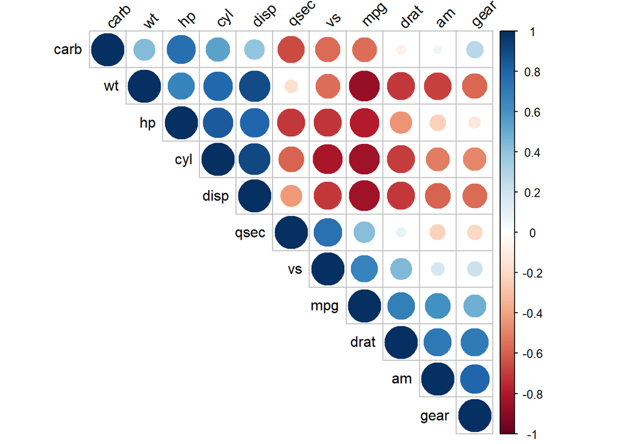

```r
# use corrplot() to plot & visualize the results on heatmap
corrplot(corResults,type="upper",order="hclust",tl.col="black",tl.srt=45)
```